# 1_simple_conformal_maps

## **Some examples of conformal maps**

I will try to plot a few simple functions f(z). This will also be a good practice using Jupyter.

Let $z$ denote a complex variable  
$z = x + iy$  
where $x$ and $y$ are real, and $i$ is the 'number' for which  
$e^{\pi i} = -1$

**1. The function $f(z,a,n) = z^n$**

The charts below show the functions $z^2, \ \sqrt{z}, \ z^{1/3}$

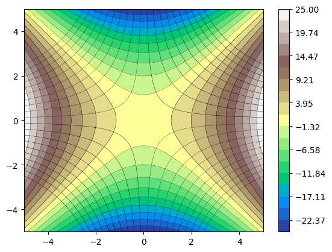

$f(z) = z^2$

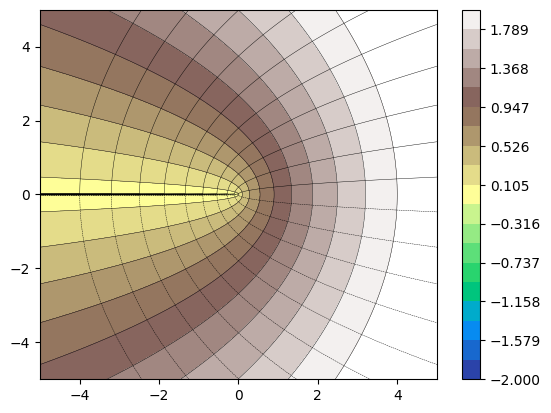

$f(z) = \sqrt{z}$

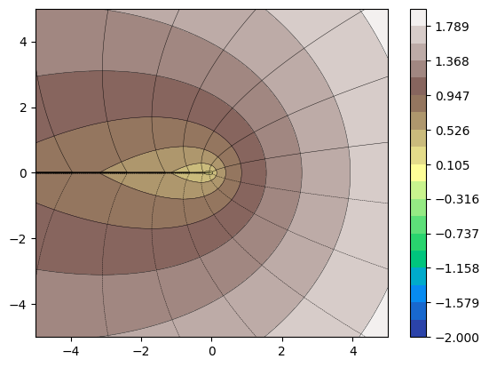

$f(z) = z^{1/3}$

**2. The function $f(z) = cos(z)$**

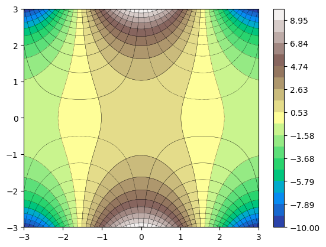

$f(z) = cos(z)$

**3. The function $f(z) = ln(z)$**

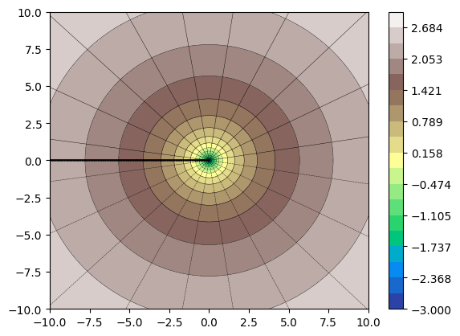

$f(z) = ln(z)$

**4. The function $f(z) = z + 1/\bar{z}$**

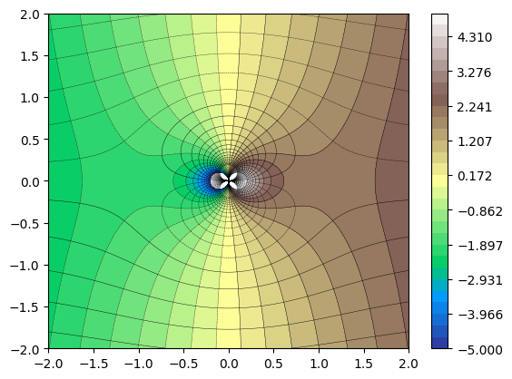

$f(z) = z + 1/\bar{z}$

**Next steps**

This ends our first look at conformal mapping of elementary functions.  
I will now be reading the book 'Schwarz-Christoffel Mapping' (SCM, 2002) by T.A. Driscoll and L.N. Trefethen  
to understand how to map regions to other regions, with the hope of finding some practical examples of  
flow nets related to groundwater flow and possibly also stress distribution.

For a preview, let's look at the first interesting map from SCM:

**The map from the unit disk to the half plane**

$f(z) = a + c/(z - z0)$  
where $a$ and $c$ are complex constants

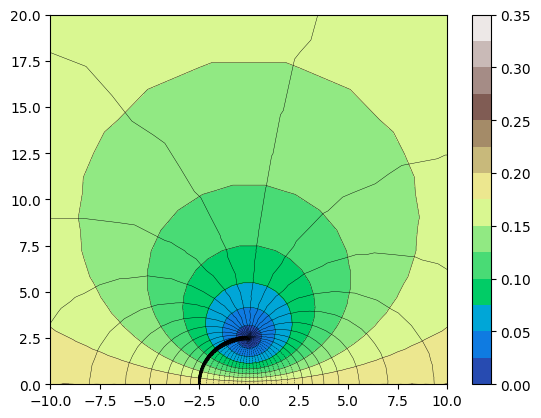

The above figure shows, under the mapping of $f(z)$, lines of constant $r$ and constant $\theta$, for $z = re^{i\theta}$.

.... to be continued.